# Project 3 (Red Wine Quality Analysis) by Mihir Majmundar

# Univariate Plots Section

```
##  [1] "X"                    "fixed.acidity"        "volatile.acidity"
##  [4] "citric.acid"          "residual.sugar"       "chlorides"
##  [7] "free.sulfur.dioxide"  "total.sulfur.dioxide" "density"
## [10] "pH"                   "sulphates"            "alcohol"
## [13] "quality"
```

```
## [1] 1599
```

```
## [1] 13
```

```
##        X          fixed.acidity   volatile.acidity  citric.acid
##  Min.   :   1.0   Min.   : 4.60   Min.   :0.1200   Min.   :0.000
##  1st Qu.: 400.5   1st Qu.: 7.10   1st Qu.:0.3900   1st Qu.:0.090
##  Median : 800.0   Median : 7.90   Median :0.5200   Median :0.260
##  Mean   : 800.0   Mean   : 8.32   Mean   :0.5278   Mean   :0.271
##  3rd Qu.:1199.5   3rd Qu.: 9.20   3rd Qu.:0.6400   3rd Qu.:0.420
##  Max.   :1599.0   Max.   :15.90   Max.   :1.5800   Max.   :1.000
##  residual.sugar     chlorides       free.sulfur.dioxide
##  Min.   : 0.900   Min.   :0.01200   Min.   : 1.00
##  1st Qu.: 1.900   1st Qu.:0.07000   1st Qu.: 7.00
##  Median : 2.200   Median :0.07900   Median :14.00
##  Mean   : 2.539   Mean   :0.08747   Mean   :15.87
##  3rd Qu.: 2.600   3rd Qu.:0.09000   3rd Qu.:21.00
##  Max.   :15.500   Max.   :0.61100   Max.   :72.00
##  total.sulfur.dioxide    density             pH          sulphates
##  Min.   :  6.00       Min.   :0.9901   Min.   :2.740   Min.   :0.3300
##  1st Qu.: 22.00       1st Qu.:0.9956   1st Qu.:3.210   1st Qu.:0.5500
##  Median : 38.00       Median :0.9968   Median :3.310   Median :0.6200
##  Mean   : 46.47       Mean   :0.9967   Mean   :3.311   Mean   :0.6581
##  3rd Qu.: 62.00       3rd Qu.:0.9978   3rd Qu.:3.400   3rd Qu.:0.7300
##  Max.   :289.00       Max.   :1.0037   Max.   :4.010   Max.   :2.0000
##     alcohol         quality
##  Min.   : 8.40   Min.   :3.000
##  1st Qu.: 9.50   1st Qu.:5.000
##  Median :10.20   Median :6.000
##  Mean   :10.42   Mean   :5.636
##  3rd Qu.:11.10   3rd Qu.:6.000
##  Max.   :14.90   Max.   :8.000
```

Most of the wine quality fall between 5 and 6. Average alcohol level is 10%. Wine is acidic, max pH level is 4.

```
## Most of the wine quality fall between 5 and 6. Average alcohol level is 10%. Wine is acidic, max pH level is 4.
```

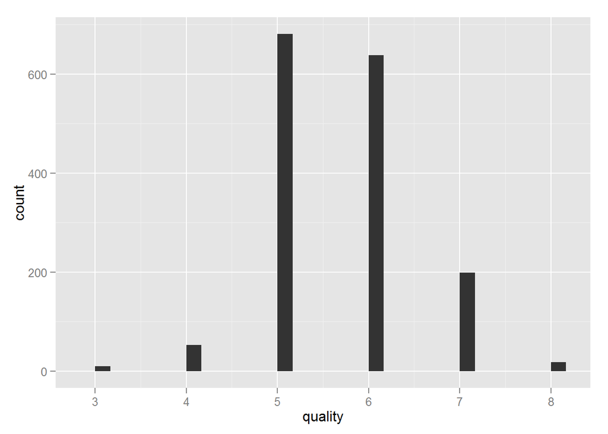

```
## After adjusting binwidth to 1, Histogram looks better
```

```
##    Min. 1st Qu.  Median    Mean 3rd Qu.    Max.
##   3.000   5.000   6.000   5.636   6.000   8.000
```

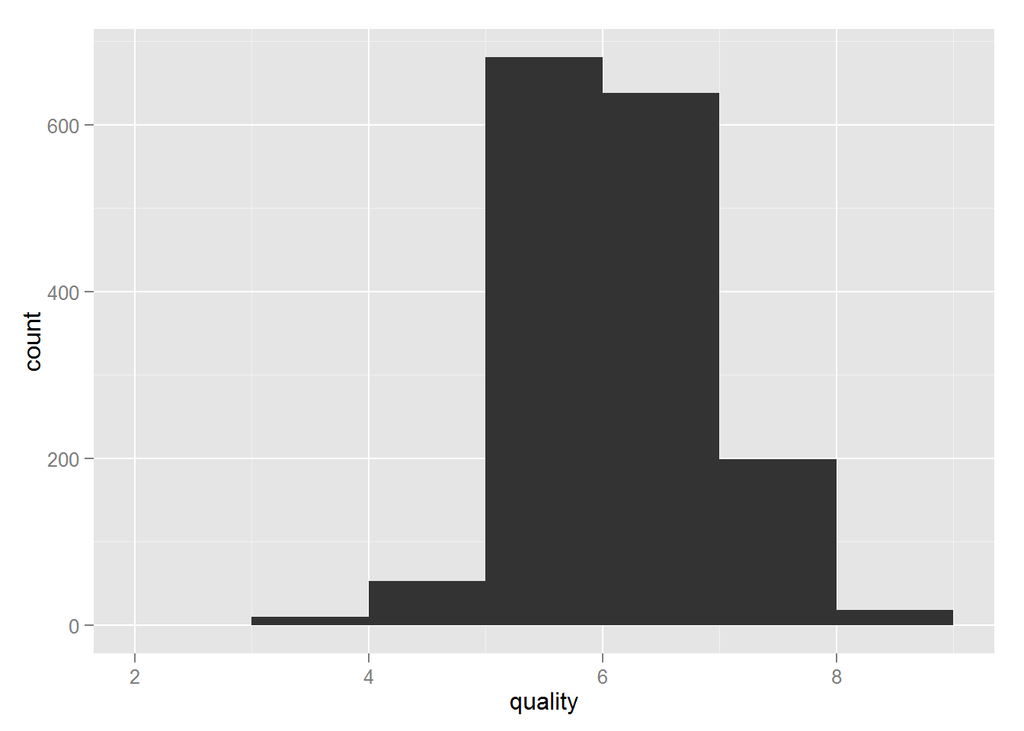

```
##    Min. 1st Qu.  Median    Mean 3rd Qu.    Max.
##   3.000   5.000   6.000   5.636   6.000   8.000
```

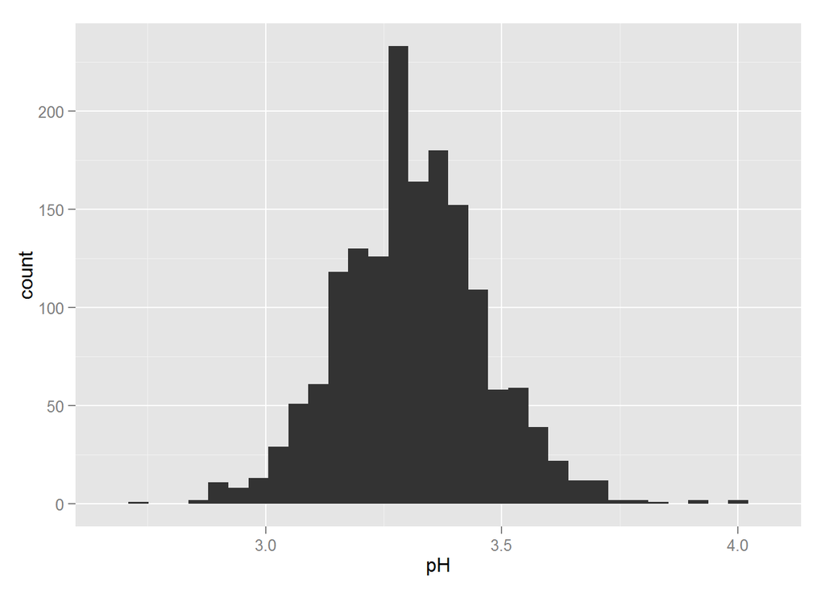

```
##    Min. 1st Qu.  Median    Mean 3rd Qu.    Max.
##   2.740   3.210   3.310   3.311   3.400   4.010
```

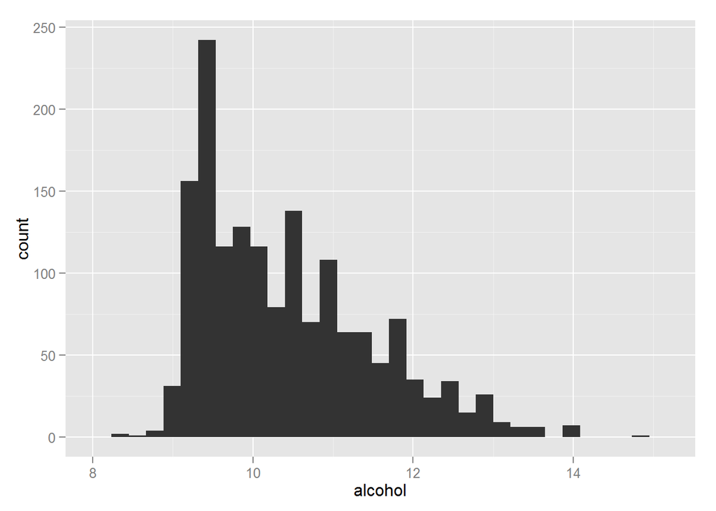

```
##    Min. 1st Qu.  Median    Mean 3rd Qu.    Max.
##    8.40    9.50   10.20   10.42   11.10   14.90
```

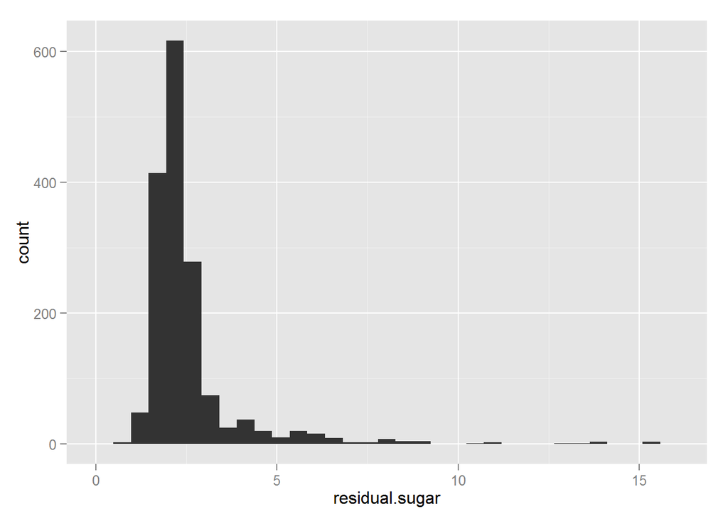

```
##    Min. 1st Qu.  Median    Mean 3rd Qu.    Max.
##   0.900   1.900   2.200   2.539   2.600  15.500
```

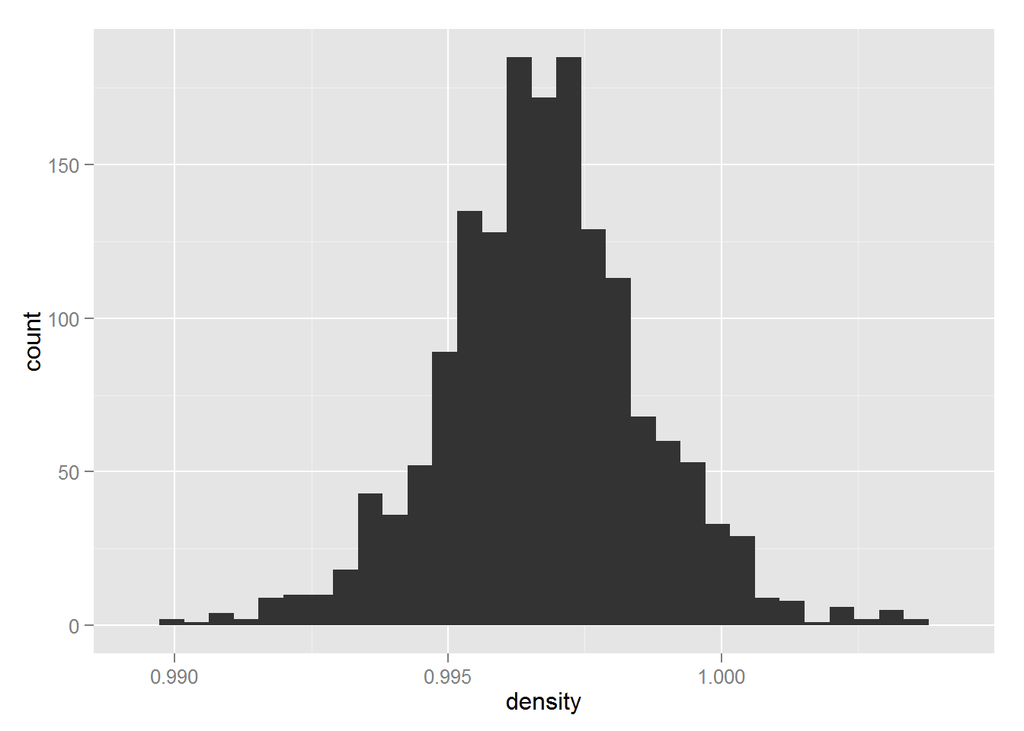

```
##    Min. 1st Qu.  Median    Mean 3rd Qu.    Max.
##  0.9901  0.9956  0.9968  0.9967  0.9978  1.0040
```

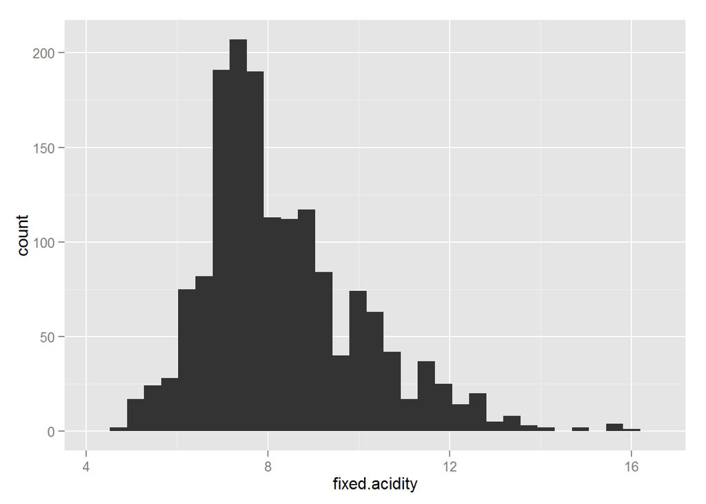

```
##    Min. 1st Qu.  Median    Mean 3rd Qu.    Max.
##    4.60    7.10    7.90    8.32    9.20   15.90
```

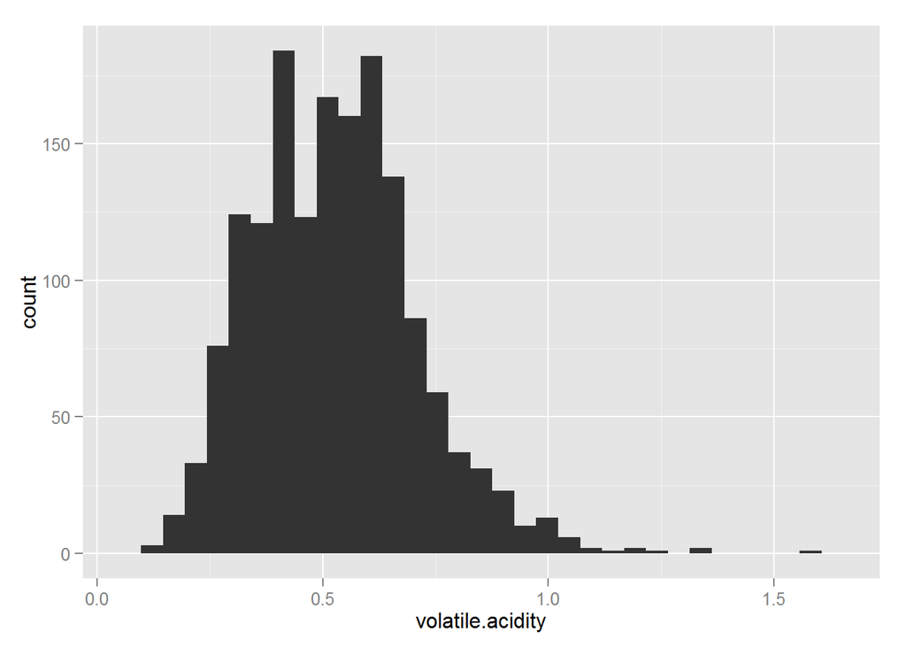

```
##    Min. 1st Qu.  Median    Mean 3rd Qu.    Max.
##  0.1200  0.3900  0.5200  0.5278  0.6400  1.5800
```

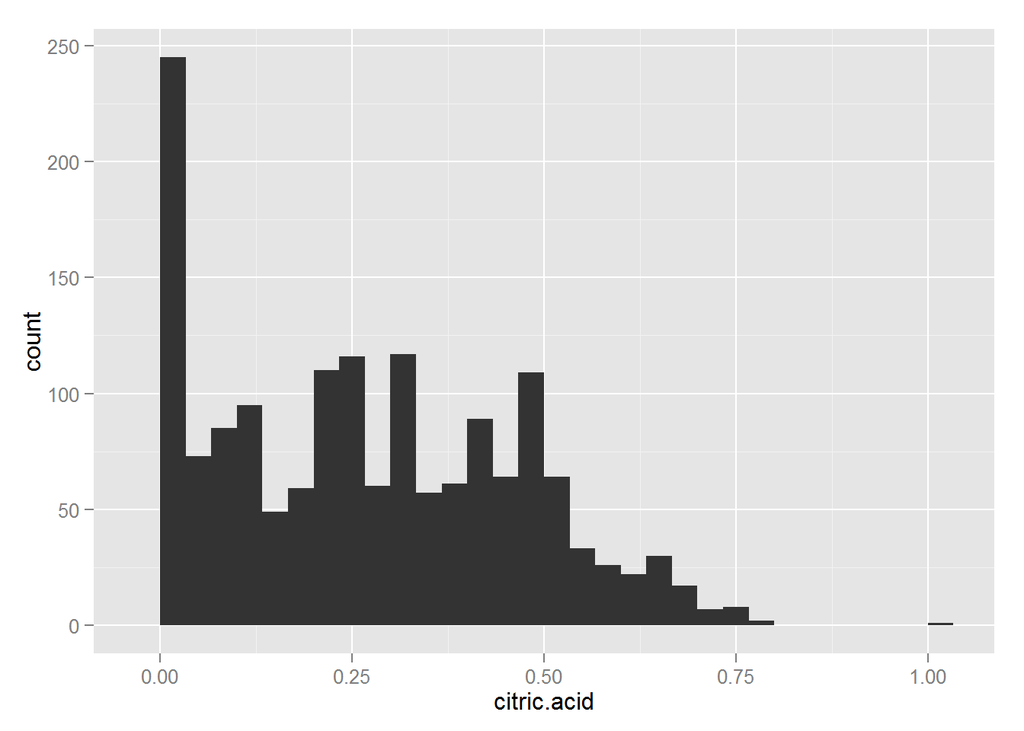

```
##    Min. 1st Qu.  Median    Mean 3rd Qu.    Max.
##   0.000   0.090   0.260   0.271   0.420   1.000
```

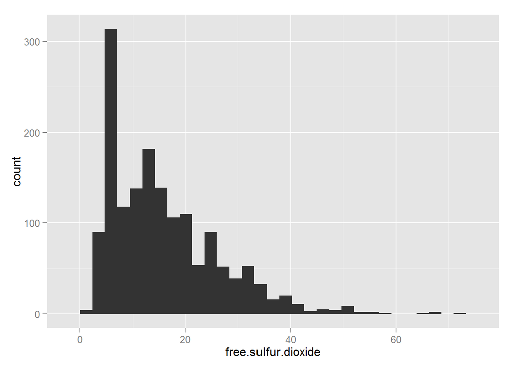

```
##    Min. 1st Qu.  Median    Mean 3rd Qu.    Max.
##    1.00    7.00   14.00   15.87   21.00   72.00
```

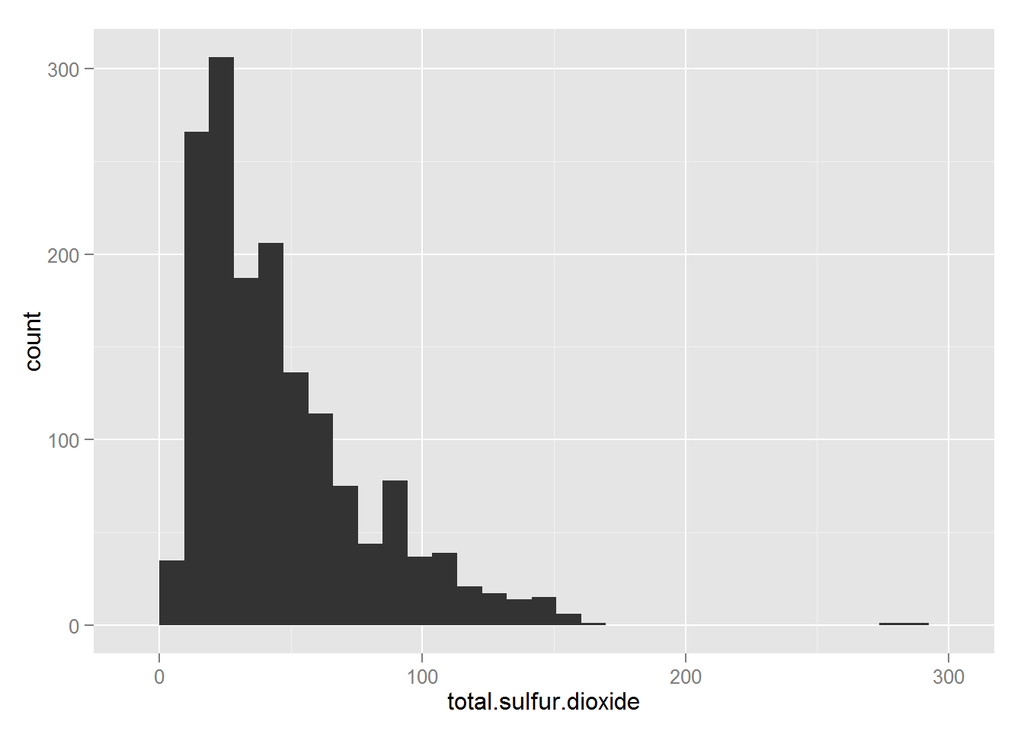

```
##    Min. 1st Qu.  Median    Mean 3rd Qu.    Max.
##    6.00   22.00   38.00   46.47   62.00  289.00
```

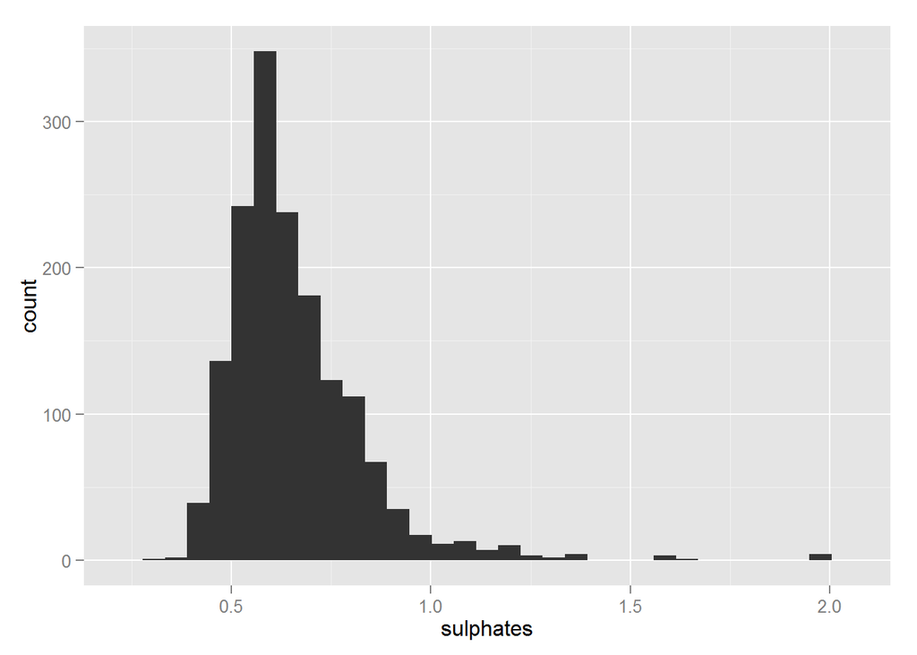

```
##    Min. 1st Qu.  Median    Mean 3rd Qu.    Max.
##  0.3300  0.5500  0.6200  0.6581  0.7300  2.0000
```

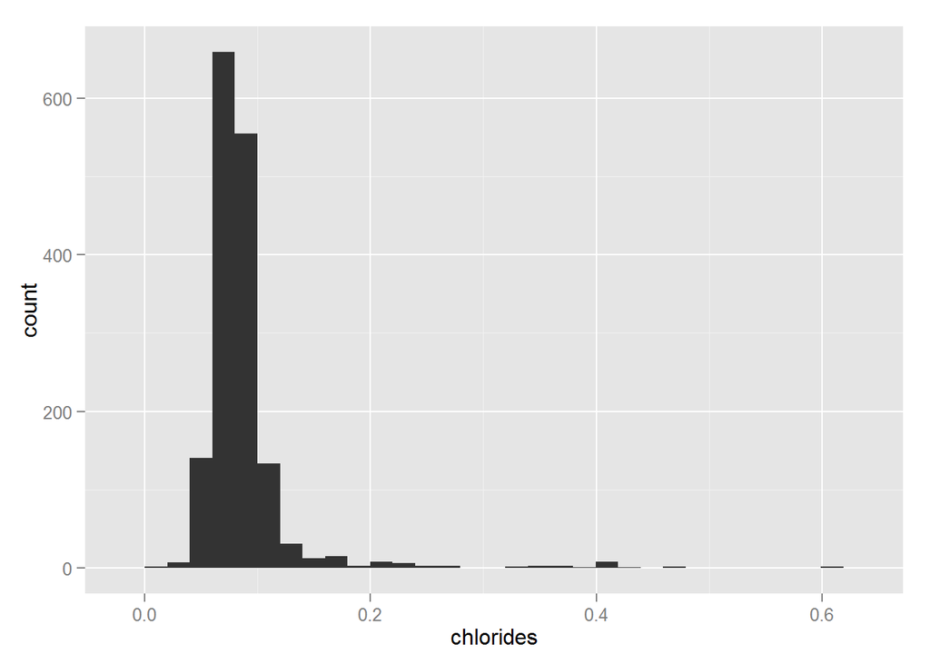

```
##    Min. 1st Qu.  Median    Mean 3rd Qu.    Max.
## 0.01200 0.07000 0.07900 0.08747 0.09000 0.61100
```

# Univariate Analysis

### What is the structure of your dataset?

There are 1,599 observation in the dataset with 13 features (X(id), fixed.acidity, volatile.acidity, citric.acid, residual.sugar, chlorides, free.sulfur.dioxide, total.sulfur.dioxide, density, pH, sulphates, alcohol, quality). Quality is output variable and other 11 are input variable. X is unique id for each observation.

All variables are numeric.

### What is/are the main feature(s) of interest in your dataset?

The main feature of the data set is quality of red wine. There are different 11 input variable with have some impact on the quality of wine. With some of the variable, I will be able to create predictive model for the red wine quality.

### What other features in the dataset do you think will help support your investigation into your feature(s) of interest?

residual sugar, density, pH, sulphates, alcohol and acidity are other features in the dataset that will help to investigate quality of wine.

### Did you create any new variables from existing variables in the dataset?

I have not created a new variable from existing variables in the dataset.

### Of the features you investigated, were there any unusual distributions? Did you perform any operations on the data to tidy, adjust, or change the form of the data? If so, why did you do this?

Quality histogram shows the normal distribution. I have not perform any operation on the data.

# Bivariate Plots Section

```
##                                 X fixed.acidity volatile.acidity
## X                     1.000000000   -0.26848392     -0.008815099
## fixed.acidity        -0.268483920    1.00000000     -0.256130895
## volatile.acidity     -0.008815099   -0.25613089      1.000000000
## citric.acid          -0.153551355    0.67170343     -0.552495685
## residual.sugar       -0.031260835    0.11477672      0.001917882
## chlorides            -0.119868519    0.09370519      0.061297772
## free.sulfur.dioxide   0.090479643   -0.15379419     -0.010503827
## total.sulfur.dioxide -0.117849669   -0.11318144      0.076470005
## density              -0.368372087    0.66804729      0.022026232
## pH                    0.136005328   -0.68297819      0.234937294
## sulphates            -0.125306999    0.18300566     -0.260986685
## alcohol               0.245122841   -0.06166827     -0.202288027
## quality               0.066452608    0.12405165     -0.390557780
##                      citric.acid residual.sugar    chlorides
## X                    -0.15355136   -0.031260835 -0.119868519
## fixed.acidity         0.67170343    0.114776724  0.093705186
## volatile.acidity     -0.55249568    0.001917882  0.061297772
## citric.acid           1.00000000    0.143577162  0.203822914
## residual.sugar        0.14357716    1.000000000  0.055609535
## chlorides             0.20382291    0.055609535  1.000000000
## free.sulfur.dioxide  -0.06097813    0.187048995  0.005562147
## total.sulfur.dioxide  0.03553302    0.203027882  0.047400468
## density               0.36494718    0.355283371  0.200632327
## pH                   -0.54190414   -0.085652422 -0.265026131
## sulphates             0.31277004    0.005527121  0.371260481
## alcohol               0.10990325    0.042075437 -0.221140545
## quality               0.22637251    0.013731637 -0.128906560
##                      free.sulfur.dioxide total.sulfur.dioxide     density
## X                            0.090479643          -0.11784967 -0.36837209
## fixed.acidity               -0.153794193          -0.11318144  0.66804729
## volatile.acidity            -0.010503827           0.07647000  0.02202623
## citric.acid                 -0.060978129           0.03553302  0.36494718
## residual.sugar               0.187048995           0.20302788  0.35528337
## chlorides                    0.005562147           0.04740047  0.20063233
## free.sulfur.dioxide          1.000000000           0.66766645 -0.02194583
## total.sulfur.dioxide         0.667666450           1.00000000  0.07126948
## density                     -0.021945831           0.07126948  1.00000000
## pH                           0.070377499          -0.06649456 -0.34169933
## sulphates                    0.051657572           0.04294684  0.14850641
## alcohol                     -0.069408354          -0.20565394 -0.49617977
## quality                     -0.050656057          -0.18510029 -0.17491923
##                               pH    sulphates     alcohol     quality
## X                     0.13600533 -0.125306999  0.24512284  0.06645261
## fixed.acidity        -0.68297819  0.183005664 -0.06166827  0.12405165
## volatile.acidity      0.23493729 -0.260986685 -0.20228803 -0.39055778
## citric.acid          -0.54190414  0.312770044  0.10990325  0.22637251
## residual.sugar       -0.08565242  0.005527121  0.04207544  0.01373164
## chlorides            -0.26502613  0.371260481 -0.22114054 -0.12890656
## free.sulfur.dioxide   0.07037750  0.051657572 -0.06940835 -0.05065606
## total.sulfur.dioxide -0.06649456  0.042946836 -0.20565394 -0.18510029
## density              -0.34169933  0.148506412 -0.49617977 -0.17491923
## pH                    1.00000000 -0.196647602  0.20563251 -0.05773139
## sulphates            -0.19664760  1.000000000  0.09359475  0.25139708
## alcohol               0.20563251  0.093594750  1.00000000  0.47616632
## quality              -0.05773139  0.251397079  0.47616632  1.00000000
```

[figure not shown]

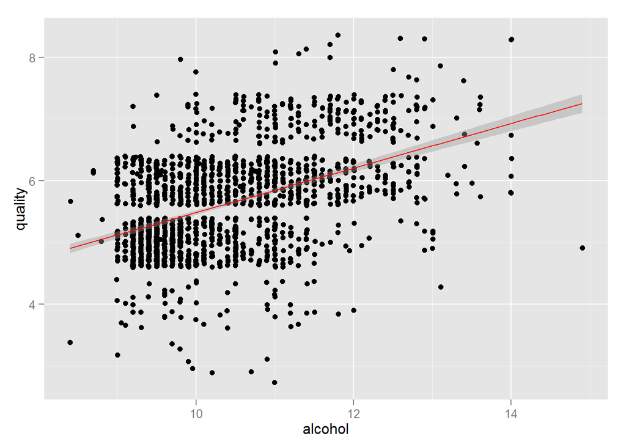

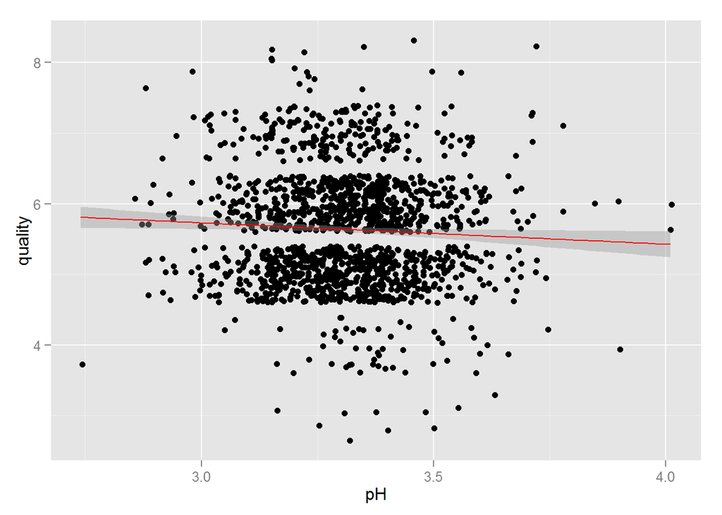

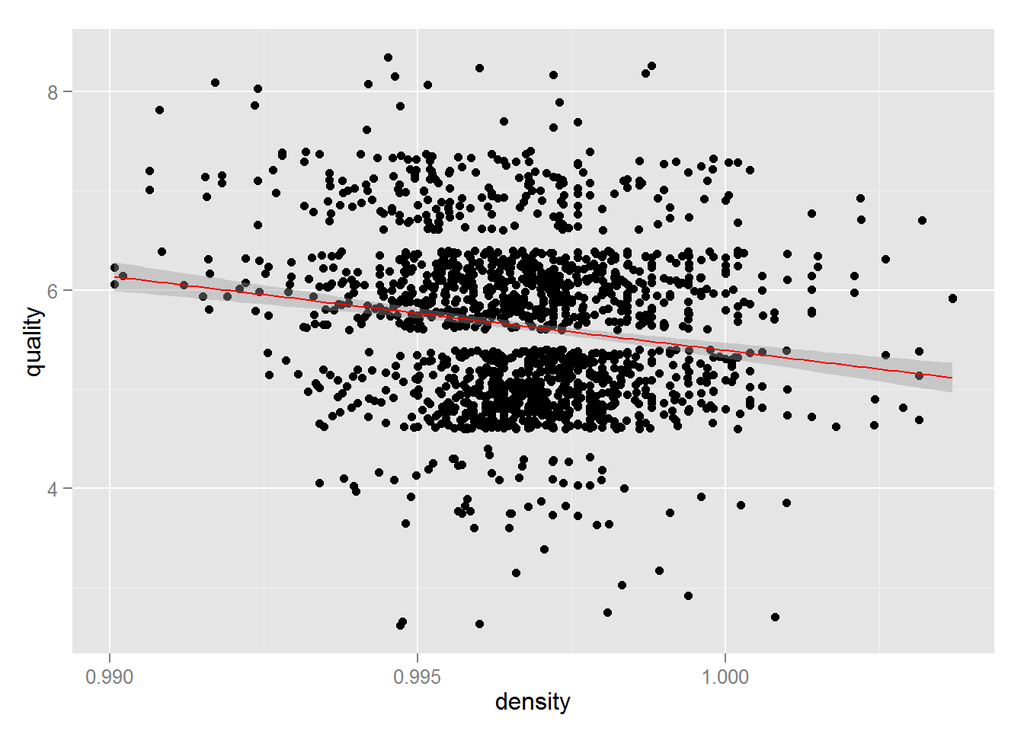

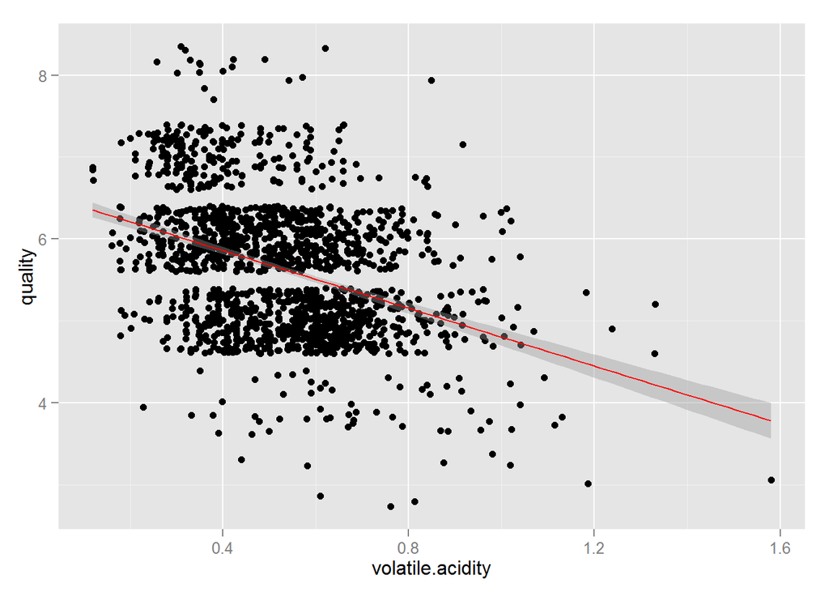

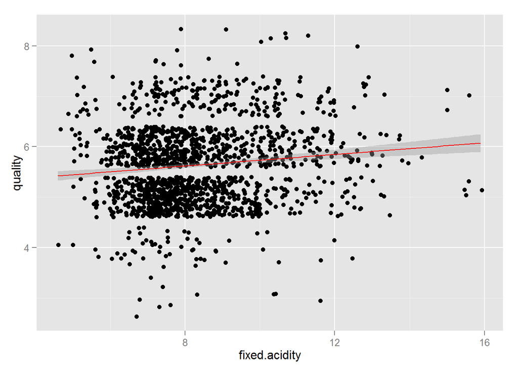

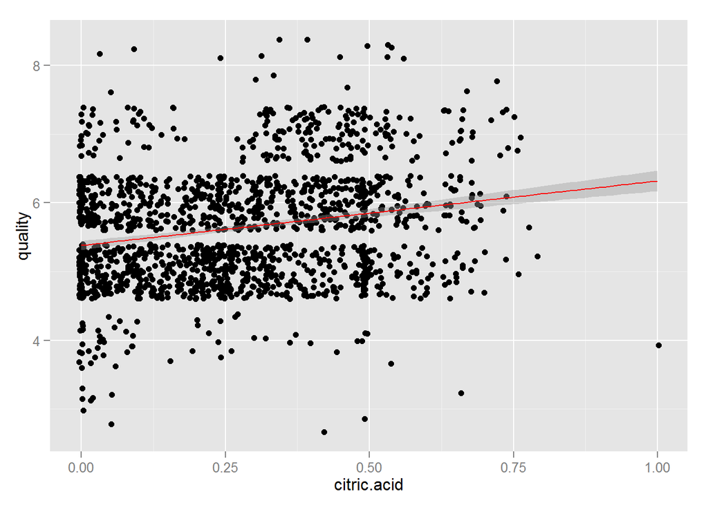

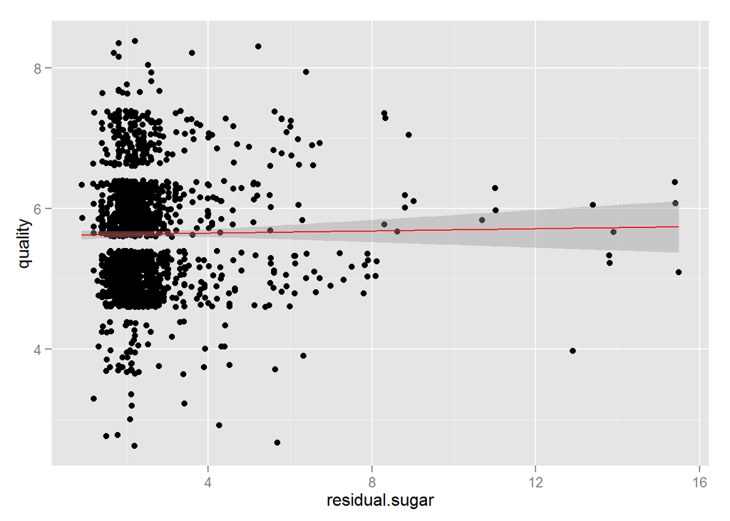

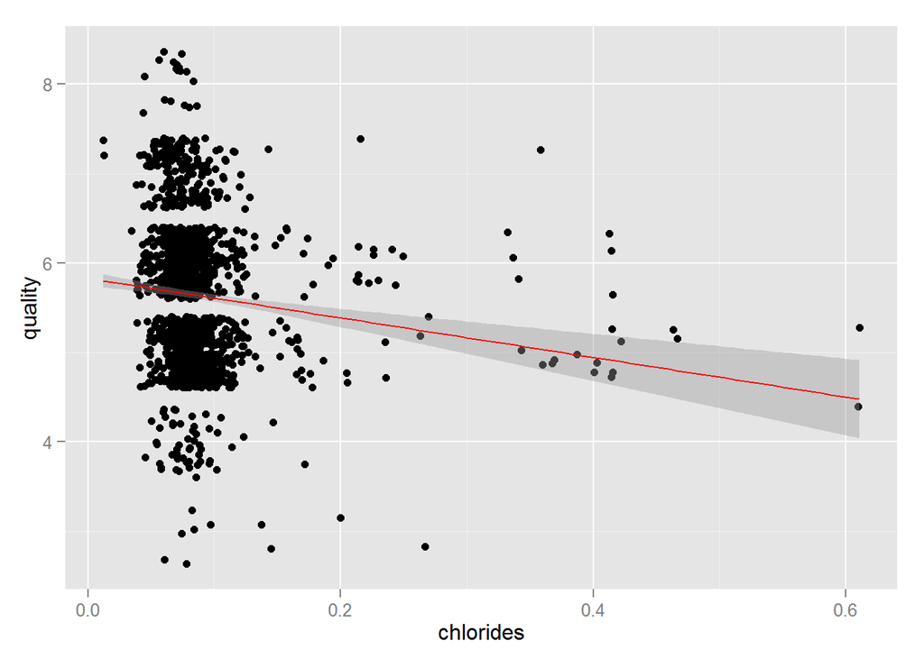

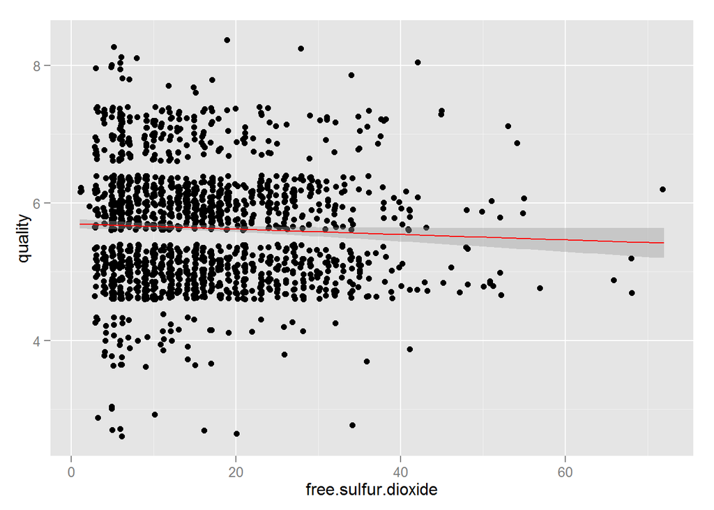

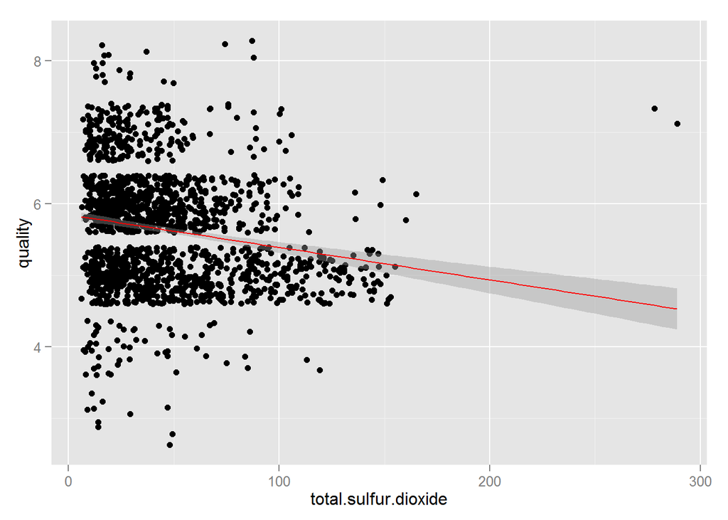

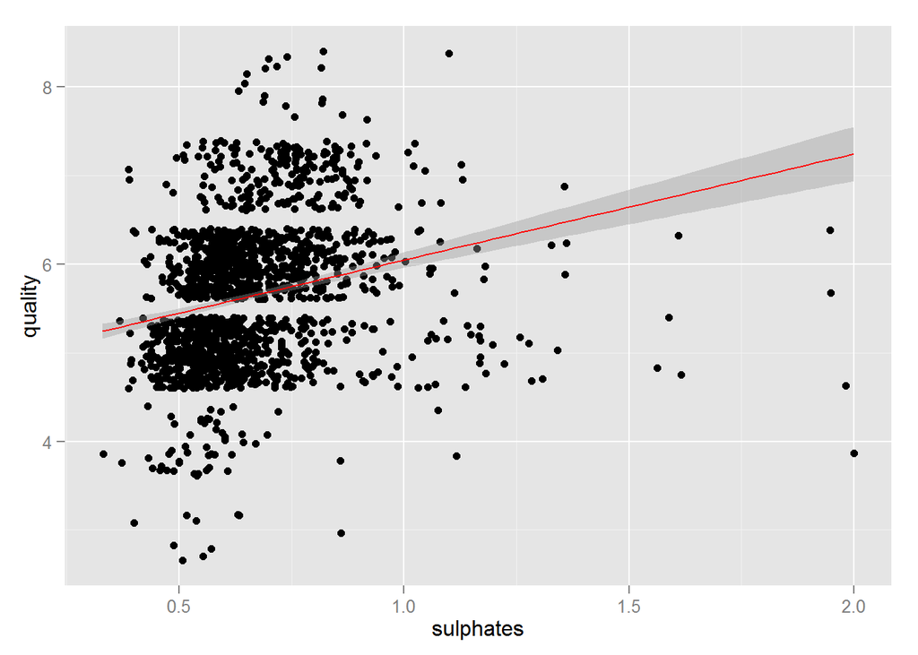

[2 more figures not shown]

# Bivariate Analysis

### Talk about some of the relationships you observed in this part of the investigation. How did the feature(s) of interest vary with other features in the dataset?

Interesting observation, Volatile acidity shows negative linear relationship where Sulphate and alcohol shows positive linear relationship.

### Did you observe any interesting relationships between the other features (not the main feature(s) of interest)?

Interesting relationship I found was in density. relationship with alcohol is negative means as value of alcohol increase, it will decrease the density of the wine where relationship with fix acidity is positive means as fix acidity increases density of the wine increases.

### What was the strongest relationship you found?

I found strongest relationship between Quality and Alcohol (0.476) (input vs output). Between the all data strongest relationship is between fix acidity and pH (-0.683) (input vs input).

# Multivariate Plots Section

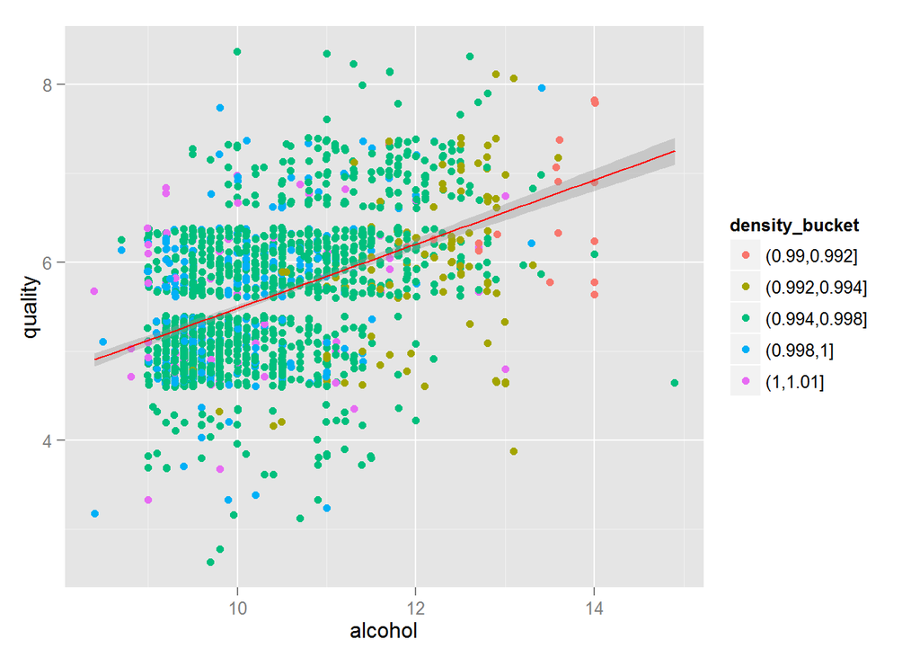

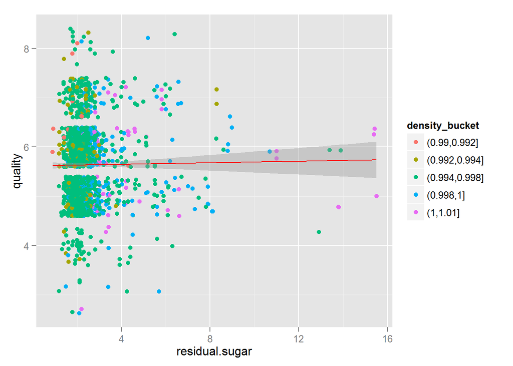

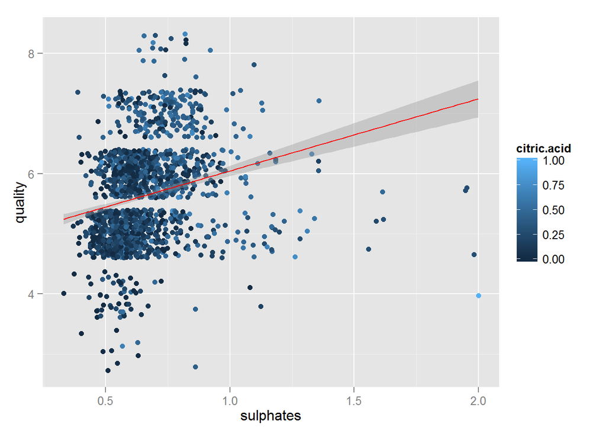

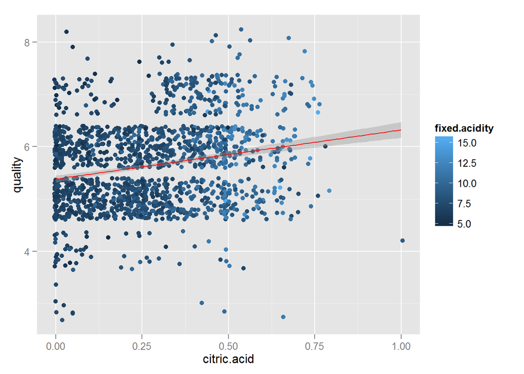

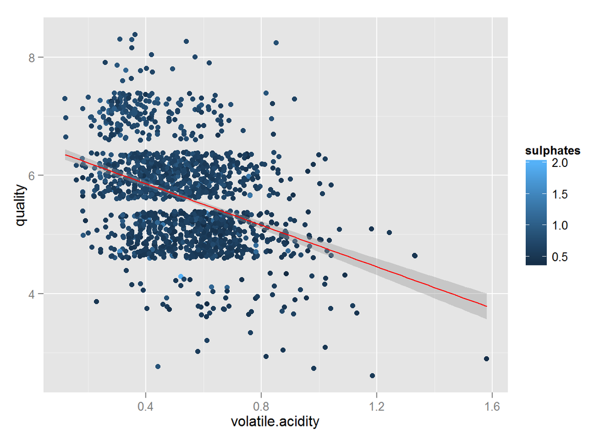

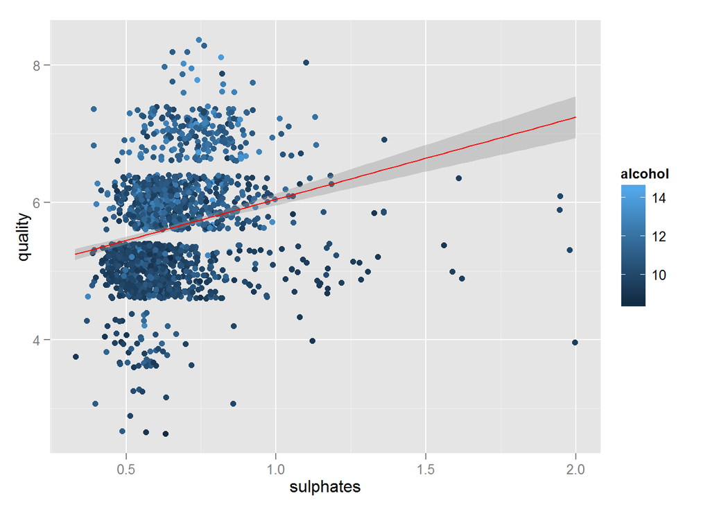

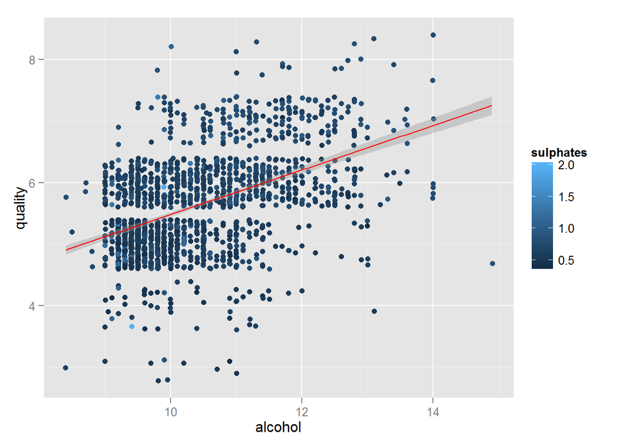

# Multivariate Analysis

### Talk about some of the relationships you observed in this part of the investigation. Were there features that strengthened each other in terms of looking at your feature(s) of interest?

As I investigate further, quality of wine shows very weak relationship with few input features. There are some strong relationship between input features like citric acid and fix acidity, pH and fix acidity. Alcohol shows the strongest relationship with Quality.

### Were there any interesting or surprising interactions between features?

Interesting part of the data is that it does not show strong consistent relationship with output vs input features. There are some strong relationship among input features and when you try to relate them and transform to relational model, they fail to show the consistency.

### OPTIONAL: Did you create any models with your dataset? Discuss the strengths and limitations of your model.

```
##
## Calls:
## m1: lm(formula = quality ~ alcohol, data = redwine)
## m2: lm(formula = quality ~ alcohol + citric.acid, data = redwine)
## m3: lm(formula = quality ~ alcohol + citric.acid + fixed.acidity,
##     data = redwine)
## m4: lm(formula = quality ~ alcohol + citric.acid + fixed.acidity +
##     volatile.acidity, data = redwine)
## m5: lm(formula = quality ~ alcohol + citric.acid + fixed.acidity +
##     volatile.acidity + sulphates, data = redwine)
## m6: lm(formula = quality ~ alcohol + citric.acid + fixed.acidity +
##     volatile.acidity + sulphates + chlorides, data = redwine)
## m7: lm(formula = quality ~ alcohol + citric.acid + fixed.acidity +
##     volatile.acidity + sulphates + chlorides + total.sulfur.dioxide,
##     data = redwine)
##
## ===========================================================================================
##                          m1        m2        m3        m4        m5        m6        m7
## -------------------------------------------------------------------------------------------
## (Intercept)            1.875***  1.830***  1.563***  2.622***  2.202***  2.363***  2.652***
##                       (0.175)   (0.171)   (0.211)   (0.219)   (0.224)   (0.228)   (0.240)
## alcohol                0.361***  0.346***  0.353***  0.325***  0.320***  0.304***  0.288***
##                       (0.017)   (0.016)   (0.017)   (0.016)   (0.016)   (0.017)   (0.017)
## citric.acid                      0.730***  0.548*** -0.314*   -0.469*** -0.335*   -0.203
##                                 (0.090)   (0.123)   (0.137)   (0.137)   (0.141)   (0.145)
## fixed.acidity                              0.030*    0.056***  0.057***  0.050***  0.037**
##                                           (0.014)   (0.013)   (0.013)   (0.013)   (0.014)
## volatile.acidity                                    -1.420*** -1.343*** -1.239*** -1.173***
##                                                     (0.115)   (0.113)   (0.117)   (0.118)
## sulphates                                                      0.701***  0.851***  0.888***
##                                                               (0.103)   (0.111)   (0.111)
## chlorides                                                               -1.430*** -1.576***
##                                                                         (0.408)   (0.408)
## total.sulfur.dioxide                                                              -0.002***
##                                                                                   (0.001)
## -------------------------------------------------------------------------------------------
## R-squared                 0.227     0.257     0.260     0.325     0.344     0.349     0.355
## adj. R-squared            0.226     0.256     0.258     0.323     0.342     0.347     0.352
## sigma                     0.710     0.696     0.696     0.664     0.655     0.653     0.650
## F                       468.267   276.595   186.376   191.617   167.023   142.224   124.875
## p                         0.000     0.000     0.000     0.000     0.000     0.000     0.000
## Log-likelihood        -1721.057 -1688.711 -1686.375 -1612.739 -1589.648 -1583.493 -1576.550
## Deviance                805.870   773.917   771.660   703.763   683.728   678.484   672.617
## AIC                    3448.114  3385.421  3382.750  3237.479  3193.297  3182.986  3171.100
## BIC                    3464.245  3406.930  3409.636  3269.742  3230.937  3226.003  3219.494
## N                      1599      1599      1599      1599      1599      1599      1599
## ===========================================================================================
```